# Food Finder

```r
ui <- fluidPage(


  # Give the page a title

  titlePanel("Food Events by Day of the Week and Week of the Semester"),



  # Generate a row with a sidebar

  sidebarLayout(



    # Define the sidebar with one input

    sidebarPanel(

      sliderTextInput("week", "Week:", choices=colnames(numfood_by_semweek_flip), animate = TRUE),

      hr(),

      helpText("Note: Weeks 0, 12, 15 had no events")),



    # Create a spot for the barplot

    mainPanel(

      plotOutput("propPlot"))

  )

)



server <- # Define a server for the Shiny app

  function(input, output) {



    # Fill in the spot we created for a plot

    output$propPlot <- renderPlot({



      # Render a barplot

      ggplot() + geom_col(aes(x = rows, y = numfood_by_semweek_flip[,input$week])) + xlab("") + ylab("Number of Food Events") + scale_y_continuous(limits = c(0, 10))

    })

  }


shinyApp(ui=ui,server=server)
```

Shiny applications not supported in static R Markdown documents

```r
#Bulk exploratory analysis

a<-masterdata%>% summarize(total_events=n(), events_with_food=sum(foodyn), events_with_snack=sum(snack), events_with_meal=sum(meal), proportion_total=n()/n(), proportion_with_food=sum(foodyn)/n(), proportion_with_snack=sum(snack)/n(), proportion_with_meal=sum(meal)/n())

##Total number analysis

total_number<-a %>% select(-proportion_total, -proportion_with_food, -proportion_with_meal, -proportion_with_snack) %>% gather(variable, value, total_events, events_with_food, events_with_snack, events_with_meal)

total_number$variable=factor(total_number$variable, levels=c("total_events", "events_with_food", "events_with_meal", "events_with_snack"))

total_number<-total_number%>%mutate(variable = recode(variable, `total_events`="Total", `events_with_food` = "Food", `events_with_meal`="Meal", `events_with_snack`="Snack"))

##Proportion analysis

total_proportion<- a %>% select(-total_events, -events_with_food, -events_with_snack, -events_with_meal) %>% gather(variable, value, proportion_total, proportion_with_food, proportion_with_meal, proportion_with_snack)

total_proportion$variable=factor(total_proportion$variable, levels=c("proportion_total", "proportion_with_food", "proportion_with_meal", "proportion_with_snack"))

total_proportion<-total_proportion%>%mutate(variable = recode(variable, `proportion_total`="Total", `proportion_with_food` = "Food", `proportion_with_meal`="Meal", `proportion_with_snack`="Snack"))
```

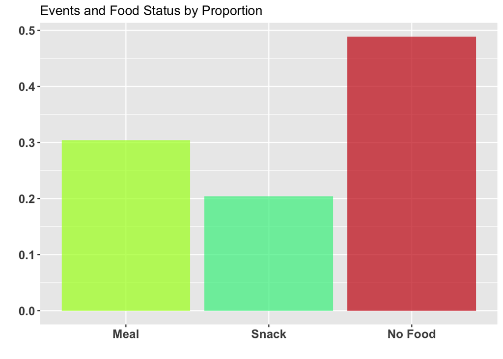

```r
library(ggthemes)

#Bulk Analysis Final

a2<-masterdata%>% summarize(total_events=n(), events_with_food=sum(foodyn), events_with_snack=sum(snack), events_with_meal=sum(meal), no_food=n()-sum(foodyn), proportion_total=n()/n(), proportion_with_food=sum(foodyn)/n(), proportion_with_snack=sum(snack)/n(), proportion_with_meal=sum(meal)/n(), proportion_no_food=(n()-sum(foodyn))/n())

 total_proportion2<- a2 %>% select(-total_events, -events_with_food, -events_with_snack, -events_with_meal, no_food) %>% gather(variable, value, proportion_total, proportion_with_food, proportion_with_meal, proportion_with_snack, proportion_no_food)

total_proportion2$variable=factor(total_proportion2$variable, levels=c("proportion_total", "proportion_with_food", "proportion_with_meal", "proportion_with_snack", "proportion_no_food"))

total_proportion2<-total_proportion2%>%mutate(variable = recode(variable, `proportion_total`="Total", `proportion_with_food` = "Food", `proportion_with_meal`="Meal", `proportion_with_snack`="Snack", `proportion_no_food`="No Food"))


# Bar chart depicting the proportion of events with food

total_proportion2 %>% filter(variable!="Total"& variable!="Food") %>% arrange(value) %>% ggplot(aes(variable, value,fill=variable)) +

  geom_bar(stat="identity", alpha=0.75) +

  theme(legend.position="none") +

  theme(axis.text.x=element_text(face="bold", size=12), axis.text.y=element_text(face="bold", size=12))+

   scale_color_economist()+
 scale_fill_manual(values=c("greenyellow", "seagreen2", "firebrick3"))+

  xlab ("")+

  ylab ("")+

  ggtitle("Events and Food Status by Proportion")
```

The above graph represents the proportion of events without food, with meal, or with snack.

```r
#Weekday analysis exploratory

masterdata$Weekday=factor(masterdata$Weekday, levels=c("Monday","Tuesday","Wednesday","Thursday","Friday","Saturday"))

weekday_analysis<-masterdata %>% group_by(Weekday) %>% summarize(events_on_day=n(), food_on_day=sum(foodyn), proportion_with_food=mean(foodyn), snack_on_day=sum(snack), proportion_with_snack=mean(snack), meal_on_day=sum(meal), proportion_with_meal=mean(meal))


weekday_analysis<-weekday_analysis %>% select(-events_on_day, -food_on_day, -snack_on_day, -meal_on_day) %>% filter(Weekday== c("Monday","Tuesday","Wednesday","Thursday","Friday","Saturday"))%>% gather(Variable, Value, proportion_with_food, proportion_with_snack, proportion_with_meal) %>% arrange(Weekday)


levels(weekday_analysis$Weekday)
```

```
## [1] "Monday"    "Tuesday"   "Wednesday" "Thursday"  "Friday"    "Saturday"
```

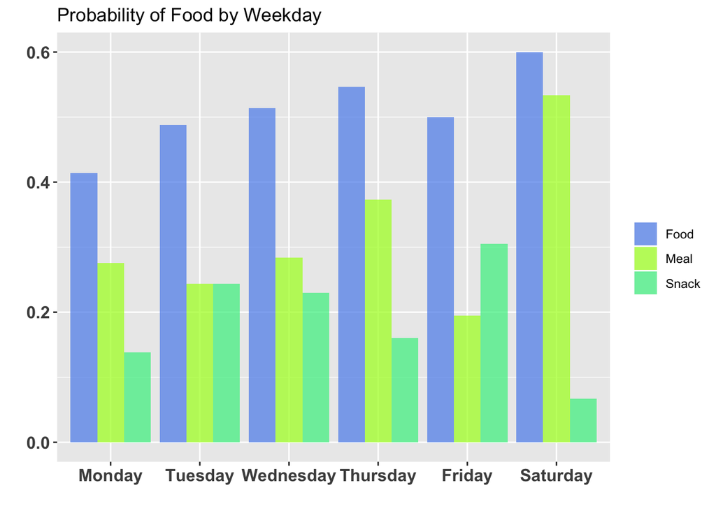

```r
weekday_analysis %>% ggplot(aes(Weekday, Value, fill=Variable))+

  geom_bar(position="dodge", stat="identity", alpha=0.75)+

  theme(axis.text.x=element_text(face="bold", size=12), axis.text.y=element_text(face="bold", size=12))+

  scale_fill_manual(values=c("cornflowerblue", "greenyellow", "seagreen2"), name="", labels=c("Food", "Meal", "Snack"))+

  xlab ("")+

  ylab ("")+

  ggtitle("Probability of Food by Weekday")
```

Exploratory graph of the proportion of events with food, with meals, and with snacks by day of the week.

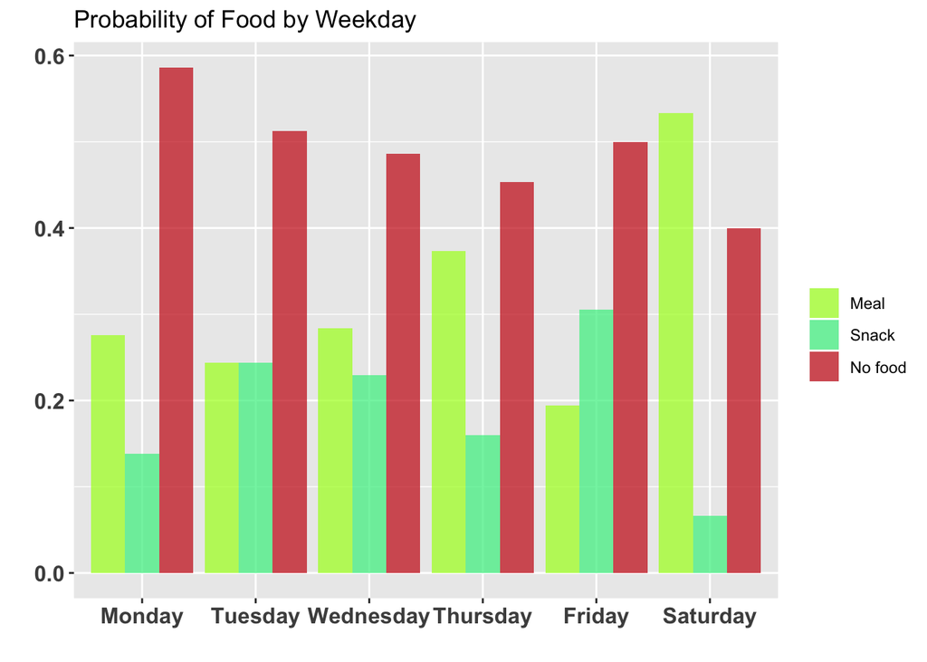

```r
#Weekday analysis final

weekday_analysis2<-masterdata %>% group_by(Weekday) %>% summarize(total_events=n(), events_with_food=sum(foodyn), events_with_snack=sum(snack), events_with_meal=sum(meal), no_food=n()-sum(foodyn), proportion_total=n()/n(), proportion_with_food=sum(foodyn)/n(), proportion_with_snack=sum(snack)/n(), proportion_with_meal=sum(meal)/n(), proportion_no_food=(n()-sum(foodyn))/n())


weekday_analysis2a<-weekday_analysis2 %>% select(-total_events, -events_with_food, -events_with_snack, -events_with_meal, -no_food) %>% filter(Weekday== c("Monday","Tuesday","Wednesday","Thursday","Friday","Saturday"))%>% gather(Variable, Value, proportion_total, proportion_with_food, proportion_with_snack, proportion_with_meal, proportion_no_food) %>% arrange(Weekday)


weekday_analysis2a$Variable=factor(weekday_analysis2a$Variable, levels=c("proportion_total", "proportion_with_food", "proportion_with_meal", "proportion_with_snack", "proportion_no_food"))


weekday_analysis2a %>% filter(Variable!="proportion_total" & Variable!="proportion_with_food") %>% ggplot(aes(Weekday, Value, fill=Variable))+

  geom_bar(position="dodge", stat="identity", alpha=0.75)+

  theme(axis.text.x=element_text(face="bold", size=12), axis.text.y=element_text(face="bold", size=12))+

  scale_fill_manual(values=c("greenyellow", "seagreen2", "firebrick3"),name="", labels=c("Meal", "Snack", "No food"))+

  xlab ("")+

  ylab ("")+

  ggtitle("Probability of Food by Weekday")
```

Depiction of the proportion of events without food, with meal and with snacks by day of the week.

```r
#Weekday number analysis final

weekday_analysis2
```

```
## # A tibble: 6 x 11
##   Weekday total_events events_with_food events_with_sna… events_with_meal
##   <fct>          <int>            <dbl>            <dbl>            <dbl>
## 1 Monday            29               12                4                8
## 2 Tuesday           41               20               10               10
## 3 Wednes…           74               38               17               21
## 4 Thursd…           75               41               12               28
## 5 Friday            36               18               11                7
## 6 Saturd…           15                9                1                8
## # ... with 6 more variables: no_food <dbl>, proportion_total <dbl>,
## #   proportion_with_food <dbl>, proportion_with_snack <dbl>,
## #   proportion_with_meal <dbl>, proportion_no_food <dbl>
```

[figure not shown]

```r
weekday_analysis2b<-weekday_analysis2 %>% select(Weekday, events_with_snack, events_with_meal, no_food) %>% filter(Weekday== c("Monday","Tuesday","Wednesday","Thursday","Friday","Saturday"))%>%gather(Variable, Value, events_with_snack, events_with_meal, no_food) %>% arrange(Weekday)

weekday_analysis2b$Variable=factor(weekday_analysis2b$Variable, levels=c("events_with_snack", "events_with_meal", "no_food"))

 weekday_analysis2b %>% ggplot(aes(Weekday, Value, fill=Variable))+

  geom_bar(position="dodge", stat="identity", alpha=0.75)+

  theme(axis.text.x=element_text(face="bold", size=12), axis.text.y=element_text(face="bold", size=12))+

  scale_fill_manual(values=c("greenyellow", "seagreen2", "firebrick3"), name="", labels=c("Meal", "Snack", "No food"))+

  xlab ("")+

  ylab ("")+

  ggtitle("Events by Weekday")
```

Number of events without food, with snacks and with meals by day of the week.

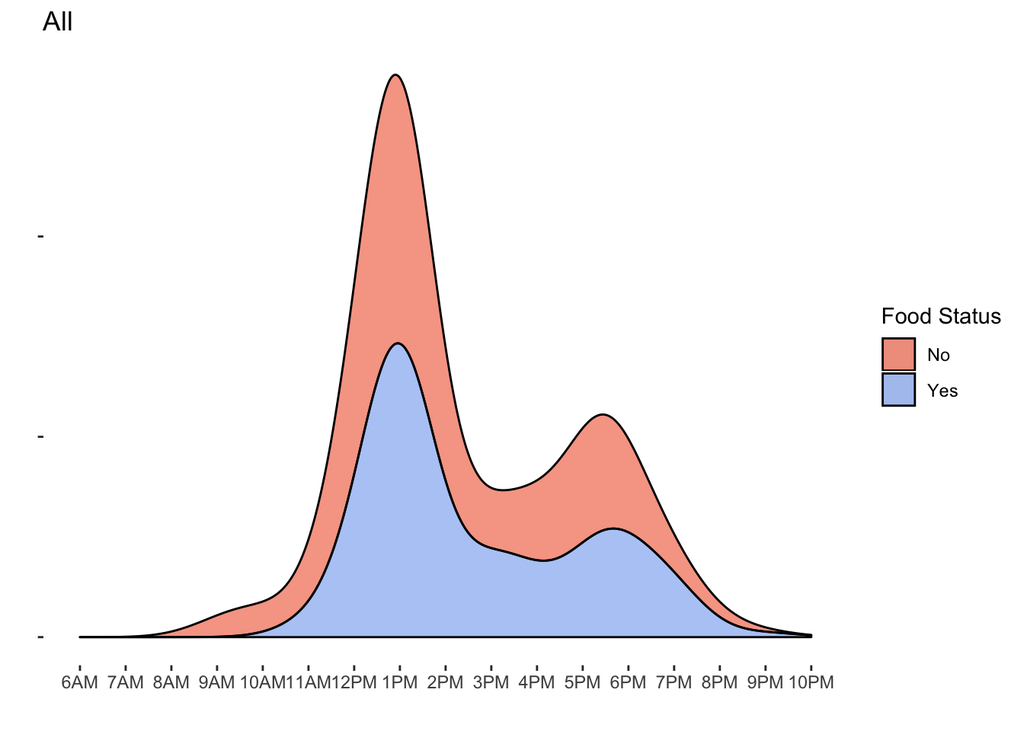

```r
#Start Time Analysis by Day


masterdata<-masterdata%>%mutate(foodynfactor=as.factor(foodyn))

masterdata %>% ggplot(aes(as.numeric(TimeStart), fill=foodynfactor))+

  geom_density(alpha=0.5, adjust=1, position="stack")+

  scale_x_continuous(limits=c(as.numeric(hms("06:00:00")),as.numeric(hms("22:00:00"))), breaks=seq(21600, 79200, 3600), labels= c("6AM", "7AM", "8AM", "9AM", "10AM", "11AM", "12PM", "1PM", "2PM", "3PM", "4PM", "5PM", "6PM", "7PM", "8PM", "9PM", "10PM"))+

  scale_fill_manual(values=c("orangered2","cornflowerblue"), name="Food Status", labels=c("No", "Yes")) +

  scale_y_continuous(labels = NULL) +

  theme(panel.background = element_blank(), panel.grid.major.y = element_blank())+

  xlab("")+

  ylab("")+

  ggtitle("All")
```

Probability distribution of events and of food at those events by start time of the event across all days.

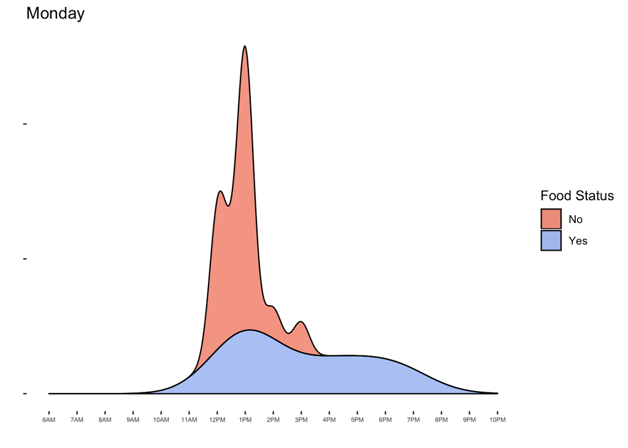

```r
masterdata%>% filter(Weekday=="Monday") %>% ggplot(aes(as.numeric(TimeStart), fill=foodynfactor))+

  geom_density(alpha=0.5, adjust=1, position="stack")+

  scale_x_continuous(limits=c(as.numeric(hms("06:00:00")),as.numeric(hms("22:00:00"))), breaks=seq(21600, 79200, 3600), labels= c("6AM", "7AM", "8AM", "9AM", "10AM", "11AM", "12PM", "1PM", "2PM", "3PM", "4PM", "5PM", "6PM", "7PM", "8PM", "9PM", "10PM"))+

  theme(axis.text.x=element_text(size=5))+

  scale_fill_manual(values=c("orangered2","cornflowerblue"),name="Food Status", labels=c("No", "Yes")) +

  scale_y_continuous(labels = NULL) +

  theme(panel.background = element_blank(), panel.grid.major.y = element_blank())+ scale_color_economist()+

  xlab("")+

  ylab("")+

  ggtitle("Monday")
```

```r
ggsave("Monday.png", scale=0.7, dpi=300)
```

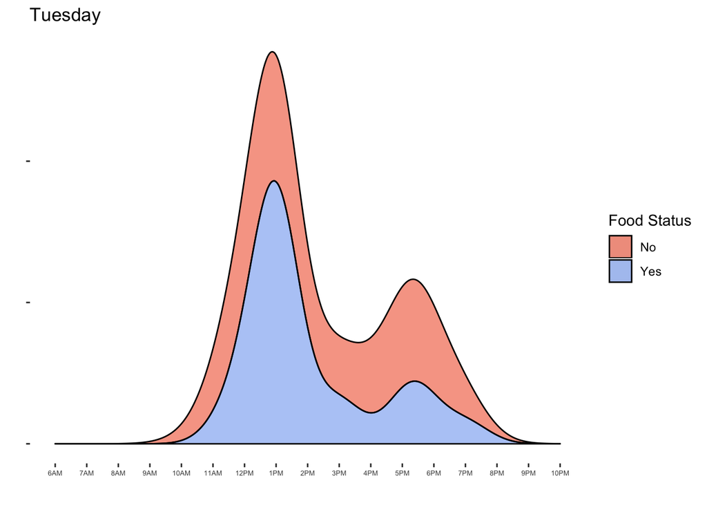

```r
masterdata%>% filter(Weekday=="Tuesday") %>% ggplot(aes(as.numeric(TimeStart), fill=foodynfactor))+

  geom_density(alpha=0.5, adjust=1, position="stack")+

  scale_x_continuous(limits=c(as.numeric(hms("06:00:00")),as.numeric(hms("22:00:00"))), breaks=seq(21600, 79200, 3600), labels= c("6AM", "7AM", "8AM", "9AM", "10AM", "11AM", "12PM", "1PM", "2PM", "3PM", "4PM", "5PM", "6PM", "7PM", "8PM", "9PM", "10PM"))+

  theme(axis.text.x=element_text(size=5))+

  scale_fill_manual(values=c("orangered2","cornflowerblue"),name="Food Status", labels=c("No", "Yes")) +

  scale_y_continuous(labels = NULL) +

  theme(panel.background = element_blank(), panel.grid.major.y = element_blank())+ scale_color_economist()+

  xlab("")+

  ylab("")+

  ggtitle("Tuesday")
```

```r
ggsave("Tuesday.png", scale=0.7, dpi=300)
```

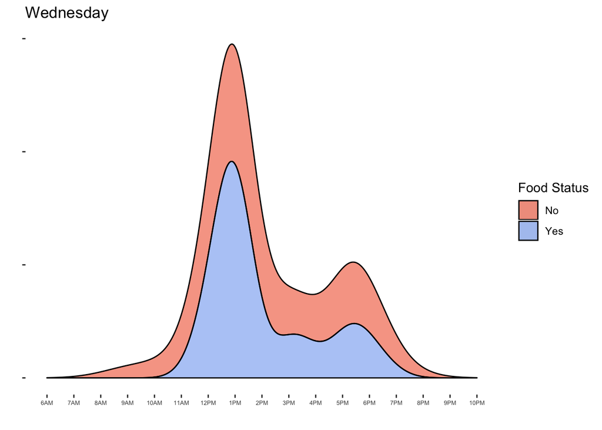

```r
masterdata%>% filter(Weekday=="Wednesday") %>% ggplot(aes(as.numeric(TimeStart), fill=foodynfactor))+

  geom_density(alpha=0.5, adjust=1, position="stack")+

  scale_x_continuous(limits=c(as.numeric(hms("06:00:00")),as.numeric(hms("22:00:00"))), breaks=seq(21600, 79200, 3600), labels= c("6AM", "7AM", "8AM", "9AM", "10AM", "11AM", "12PM", "1PM", "2PM", "3PM", "4PM", "5PM", "6PM", "7PM", "8PM", "9PM", "10PM"))+

  theme(axis.text.x=element_text(size=5))+

  scale_fill_manual(values=c("orangered2","cornflowerblue"),name="Food Status", labels=c("No", "Yes")) +

  scale_y_continuous(labels = NULL) +

  theme(panel.background = element_blank(), panel.grid.major.y = element_blank())+ scale_color_economist()+

  xlab("")+

  ylab("")+

  ggtitle("Wednesday")
```

```r
ggsave("Wednesday.png", scale=0.7, dpi=300)
```

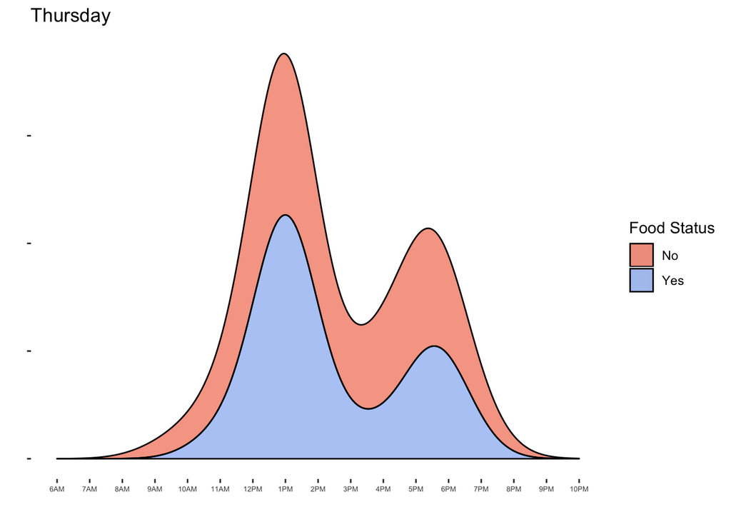

```r
masterdata%>% filter(Weekday=="Thursday") %>% ggplot(aes(as.numeric(TimeStart), fill=foodynfactor))+

  geom_density(alpha=0.5, adjust=1, position="stack")+

  scale_x_continuous(limits=c(as.numeric(hms("06:00:00")),as.numeric(hms("22:00:00"))), breaks=seq(21600, 79200, 3600), labels= c("6AM", "7AM", "8AM", "9AM", "10AM", "11AM", "12PM", "1PM", "2PM", "3PM", "4PM", "5PM", "6PM", "7PM", "8PM", "9PM", "10PM"))+

  theme(axis.text.x=element_text(size=5))+

  scale_fill_manual(values=c("orangered2","cornflowerblue"),name="Food Status", labels=c("No", "Yes")) +

  scale_y_continuous(labels = NULL) +

  theme(panel.background = element_blank(), panel.grid.major.y = element_blank())+ scale_color_economist()+

  xlab("")+

  ylab("")+

  ggtitle("Thursday")
```

```r
ggsave("Thursday.png", scale=0.7, dpi=300)
```

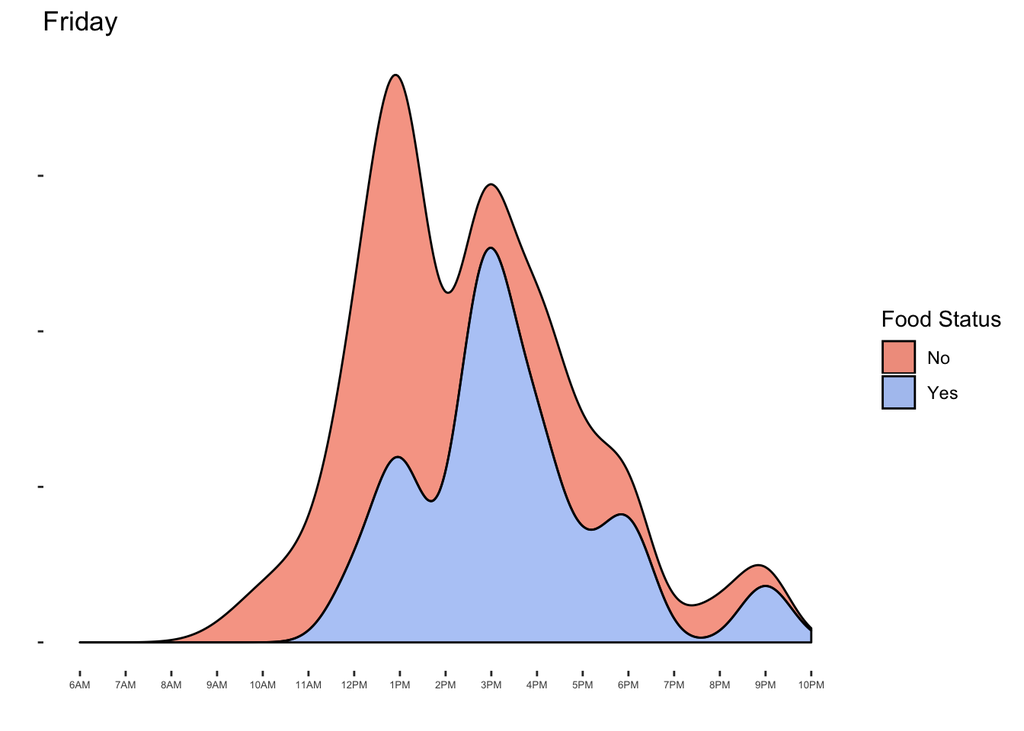

```r
masterdata%>% filter(Weekday=="Friday") %>% ggplot(aes(as.numeric(TimeStart), fill=foodynfactor))+

  geom_density(alpha=0.5, adjust=1, position="stack")+

  scale_x_continuous(limits=c(as.numeric(hms("06:00:00")),as.numeric(hms("22:00:00"))), breaks=seq(21600, 79200, 3600), labels= c("6AM", "7AM", "8AM", "9AM", "10AM", "11AM", "12PM", "1PM", "2PM", "3PM", "4PM", "5PM", "6PM", "7PM", "8PM", "9PM", "10PM"))+

  theme(axis.text.x=element_text(size=5))+

  scale_fill_manual(values=c("orangered2","cornflowerblue"),name="Food Status", labels=c("No", "Yes")) +

  scale_y_continuous(labels = NULL) + scale_color_economist()+

  theme(panel.background = element_blank(), panel.grid.major.y = element_blank())+

  xlab("")+

  ylab("")+

  ggtitle("Friday")
```

```r
ggsave("Friday.png", scale=0.7, dpi=300)
```

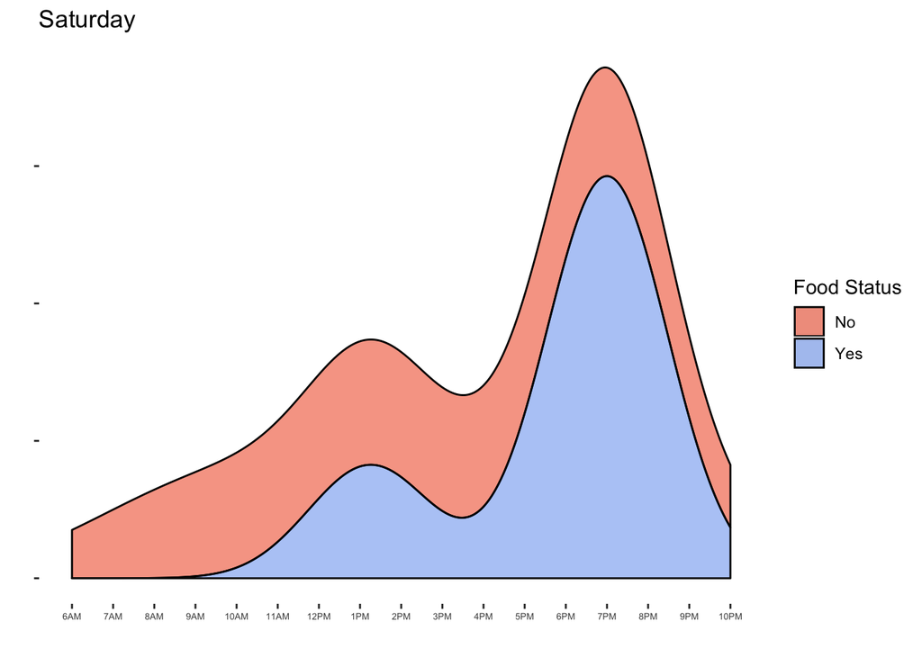

```r
masterdata%>% filter(Weekday=="Saturday") %>% ggplot(aes(as.numeric(TimeStart), fill=foodynfactor))+

  geom_density(alpha=0.5, adjust=1, position="stack")+

  scale_x_continuous(limits=c(as.numeric(hms("06:00:00")),as.numeric(hms("22:00:00"))), breaks=seq(21600, 79200, 3600), labels= c("6AM", "7AM", "8AM", "9AM", "10AM", "11AM", "12PM", "1PM", "2PM", "3PM", "4PM", "5PM", "6PM", "7PM", "8PM", "9PM", "10PM"))+

  theme(axis.text.x=element_text(size=5))+

  scale_fill_manual(values=c("orangered2","cornflowerblue"),name="Food Status", labels=c("No", "Yes")) +

  scale_y_continuous(labels = NULL) +

  theme(panel.background = element_blank(), panel.grid.major.y = element_blank())+ scale_color_economist()+

  xlab("")+

  ylab("")+

  ggtitle("Saturday")
```

```r
ggsave("Saturday.png", scale=0.7, dpi=300)
```

Probability distribution of events and of food at those events by start time of the event by weekday. This will produce graphs that will be used for an R shiny animation.

```r
#needed for rshiny
path <-getwd()
```

```r
#R shiny

library(shiny)

library(shinyWidgets)



ui <- fluidPage(

  sliderTextInput("Weekday", "Day of the Week:", choices=c("Monday", "Tuesday", "Wednesday", "Thursday", "Friday", "Saturday"),selected = c("Monday"), animate = TRUE, grid = TRUE, hide_min_max = TRUE, from_fixed = FALSE,to_fixed = FALSE, from_min = NULL, from_max = NULL, to_min = NULL,to_max = NULL, force_edges = FALSE, width = 1000, pre = NULL,post = NULL, dragRange = TRUE),

  plotOutput("graph"))



values <- reactiveValues("Monday" = "Monday.png", "Tuesday"="Tuesday.png", "Wednesday"="Wednesday.png", "Thursday"="Thursday.png", "Friday" = "Friday.png", "Saturday"="Saturday.png")



paste('red', 'dead', sep='')
```

```
## [1] "reddead"
```

```r
paste('weekday', '.png', sep='')
```

```
## [1] "weekday.png"
```

```r
server <- function(input, output) {

  output$graph <- renderImage ({

    list(src=

    file.path(path, paste(input$Weekday, '.png', sep='')))

  }, deleteFile=FALSE)

}



shinyApp(ui=ui,server=server)
```

Shiny applications not supported in static R Markdown documents

R shiny animation/interactive slider of probability distribution graphs of events and food at those events.

Takeaway - Bimodal peak - lunchtime and late afternoon/evening

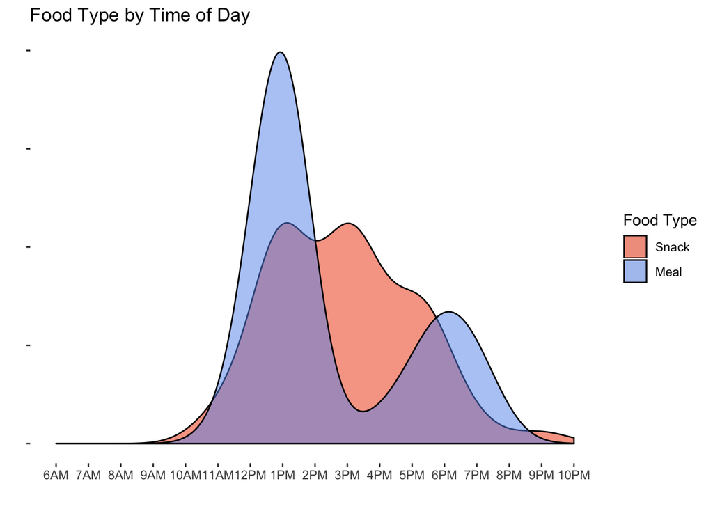

```r
#Snack vs Meal over Time

masterdata<-masterdata%>%mutate(mealfactor=as.factor(meal))


masterdata %>% filter(foodyn==1) %>% ggplot(aes(as.numeric(TimeStart), fill=mealfactor))+

  geom_density(alpha=0.5, adjust=1)+

  scale_x_continuous(limits=c(as.numeric(hms("06:00:00")),as.numeric(hms("22:00:00"))), breaks=seq(21600, 79200, 3600), labels= c("6AM", "7AM", "8AM", "9AM", "10AM", "11AM", "12PM", "1PM", "2PM", "3PM", "4PM", "5PM", "6PM", "7PM", "8PM", "9PM", "10PM"))+

  scale_fill_manual(values=c("orangered2","cornflowerblue"), name="Food Type", labels=c("Snack", "Meal")) +

  scale_y_continuous(labels = NULL) +

  theme(panel.background = element_blank(), panel.grid.major.y = element_blank())+ scale_color_economist()+

  xlab("")+

  ylab("")+

  ggtitle("Food Type by Time of Day")
```

Distribution of meals and snacks by start time of the event.